# Risk Factor Analysis

## Outcome Variable

**Outcome Variable:** stunted

## Predictor Variables

**Intervention Variable:** enwast

**Adjustment Set:**

unadjusted

## Stratifying Variables

The analysis was stratified on these variable(s):

- agecat
- studyid
- country

## Data Summary

| agecat | studyid | country | enwast | stunted | n_cell | n |
| --- | --- | --- | --- | --- | --- | --- |
| Birth | ki0047075b-MAL-ED | BANGLADESH | 0 | 0 | 174 | 241 |
| Birth | ki0047075b-MAL-ED | BANGLADESH | 0 | 1 | 27 | 241 |
| Birth | ki0047075b-MAL-ED | BANGLADESH | 1 | 0 | 36 | 241 |
| Birth | ki0047075b-MAL-ED | BANGLADESH | 1 | 1 | 4 | 241 |
| Birth | ki0047075b-MAL-ED | BRAZIL | 0 | 0 | 163 | 183 |
| Birth | ki0047075b-MAL-ED | BRAZIL | 0 | 1 | 14 | 183 |
| Birth | ki0047075b-MAL-ED | BRAZIL | 1 | 0 | 6 | 183 |
| Birth | ki0047075b-MAL-ED | BRAZIL | 1 | 1 | 0 | 183 |
| Birth | ki0047075b-MAL-ED | INDIA | 0 | 0 | 146 | 203 |
| Birth | ki0047075b-MAL-ED | INDIA | 0 | 1 | 24 | 203 |
| Birth | ki0047075b-MAL-ED | INDIA | 1 | 0 | 27 | 203 |
| Birth | ki0047075b-MAL-ED | INDIA | 1 | 1 | 6 | 203 |
| Birth | ki0047075b-MAL-ED | NEPAL | 0 | 0 | 136 | 169 |
| Birth | ki0047075b-MAL-ED | NEPAL | 0 | 1 | 12 | 169 |
| Birth | ki0047075b-MAL-ED | NEPAL | 1 | 0 | 19 | 169 |
| Birth | ki0047075b-MAL-ED | NEPAL | 1 | 1 | 2 | 169 |
| Birth | ki0047075b-MAL-ED | PERU | 0 | 0 | 248 | 279 |
| Birth | ki0047075b-MAL-ED | PERU | 0 | 1 | 25 | 279 |
| Birth | ki0047075b-MAL-ED | PERU | 1 | 0 | 5 | 279 |
| Birth | ki0047075b-MAL-ED | PERU | 1 | 1 | 1 | 279 |
| Birth | ki0047075b-MAL-ED | SOUTH AFRICA | 0 | 0 | 218 | 260 |
| Birth | ki0047075b-MAL-ED | SOUTH AFRICA | 0 | 1 | 22 | 260 |
| Birth | ki0047075b-MAL-ED | SOUTH AFRICA | 1 | 0 | 16 | 260 |
| Birth | ki0047075b-MAL-ED | SOUTH AFRICA | 1 | 1 | 4 | 260 |
| Birth | ki0047075b-MAL-ED | TANZANIA, UNITED REPUBLIC OF | 0 | 0 | 104 | 118 |
| Birth | ki0047075b-MAL-ED | TANZANIA, UNITED REPUBLIC OF | 0 | 1 | 12 | 118 |
| Birth | ki0047075b-MAL-ED | TANZANIA, UNITED REPUBLIC OF | 1 | 0 | 1 | 118 |
| Birth | ki0047075b-MAL-ED | TANZANIA, UNITED REPUBLIC OF | 1 | 1 | 1 | 118 |
| Birth | ki1000108-CMC-V-BCS-2002 | INDIA | 0 | 0 | 65 | 85 |
| Birth | ki1000108-CMC-V-BCS-2002 | INDIA | 0 | 1 | 9 | 85 |

[output cut: 314 more lines]

The following strata were considered:

- agecat: 24 months, studyid: ki0047075b-MAL-ED, country: BANGLADESH
- agecat: 24 months, studyid: ki0047075b-MAL-ED, country: BRAZIL
- agecat: 24 months, studyid: ki0047075b-MAL-ED, country: INDIA
- agecat: 24 months, studyid: ki0047075b-MAL-ED, country: NEPAL
- agecat: 24 months, studyid: ki0047075b-MAL-ED, country: PERU
- agecat: 24 months, studyid: ki0047075b-MAL-ED, country: SOUTH AFRICA
- agecat: 24 months, studyid: ki0047075b-MAL-ED, country: TANZANIA, UNITED REPUBLIC OF
- agecat: 24 months, studyid: ki1000108-CMC-V-BCS-2002, country: INDIA
- agecat: 24 months, studyid: ki1000108-IRC, country: INDIA
- agecat: 24 months, studyid: ki1017093-NIH-Birth, country: BANGLADESH
- agecat: 24 months, studyid: ki1017093b-PROVIDE, country: BANGLADESH
- agecat: 24 months, studyid: ki1017093c-NIH-Crypto, country: BANGLADESH
- agecat: 24 months, studyid: ki1066203-TanzaniaChild2, country: TANZANIA, UNITED REPUBLIC OF
- agecat: 24 months, studyid: ki1101329-Keneba, country: GAMBIA
- agecat: 24 months, studyid: ki1113344-GMS-Nepal, country: NEPAL
- agecat: 24 months, studyid: ki1114097-CMIN, country: BANGLADESH
- agecat: 24 months, studyid: ki1114097-CMIN, country: GUINEA-BISSAU
- agecat: 24 months, studyid: ki1114097-CMIN, country: PERU
- agecat: 24 months, studyid: ki1114097-CONTENT, country: PERU
- agecat: 24 months, studyid: ki1119695-PROBIT, country: BELARUS
- agecat: 24 months, studyid: ki1126311-ZVITAMBO, country: ZIMBABWE
- agecat: 24 months, studyid: ki1135781-COHORTS, country: GUATEMALA
- agecat: 24 months, studyid: ki1135781-COHORTS, country: INDIA
- agecat: 24 months, studyid: ki1135781-COHORTS, country: PHILIPPINES
- agecat: 24 months, studyid: ki1148112-LCNI-5, country: MALAWI
- agecat: 24 months, studyid: kiGH5241-JiVitA-3, country: BANGLADESH
- agecat: 24 months, studyid: kiGH5241-JiVitA-4, country: BANGLADESH
- agecat: 6 months, studyid: ki0047075b-MAL-ED, country: BANGLADESH
- agecat: 6 months, studyid: ki0047075b-MAL-ED, country: BRAZIL
- agecat: 6 months, studyid: ki0047075b-MAL-ED, country: INDIA
- agecat: 6 months, studyid: ki0047075b-MAL-ED, country: NEPAL
- agecat: 6 months, studyid: ki0047075b-MAL-ED, country: PERU
- agecat: 6 months, studyid: ki0047075b-MAL-ED, country: SOUTH AFRICA
- agecat: 6 months, studyid: ki0047075b-MAL-ED, country: TANZANIA, UNITED REPUBLIC OF
- agecat: 6 months, studyid: ki1000108-CMC-V-BCS-2002, country: INDIA
- agecat: 6 months, studyid: ki1000108-IRC, country: INDIA
- agecat: 6 months, studyid: ki1000109-EE, country: PAKISTAN
- agecat: 6 months, studyid: ki1000109-ResPak, country: PAKISTAN
- agecat: 6 months, studyid: ki1000304b-SAS-CompFeed, country: INDIA
- agecat: 6 months, studyid: ki1000304b-SAS-FoodSuppl, country: INDIA
- agecat: 6 months, studyid: ki1017093-NIH-Birth, country: BANGLADESH
- agecat: 6 months, studyid: ki1017093b-PROVIDE, country: BANGLADESH
- agecat: 6 months, studyid: ki1017093c-NIH-Crypto, country: BANGLADESH
- agecat: 6 months, studyid: ki1066203-TanzaniaChild2, country: TANZANIA, UNITED REPUBLIC OF
- agecat: 6 months, studyid: ki1101329-Keneba, country: GAMBIA
- agecat: 6 months, studyid: ki1112895-Guatemala BSC, country: GUATEMALA
- agecat: 6 months, studyid: ki1113344-GMS-Nepal, country: NEPAL
- agecat: 6 months, studyid: ki1114097-CMIN, country: BANGLADESH
- agecat: 6 months, studyid: ki1114097-CMIN, country: BRAZIL
- agecat: 6 months, studyid: ki1114097-CMIN, country: GUINEA-BISSAU
- agecat: 6 months, studyid: ki1114097-CMIN, country: PERU
- agecat: 6 months, studyid: ki1114097-CONTENT, country: PERU
- agecat: 6 months, studyid: ki1119695-PROBIT, country: BELARUS
- agecat: 6 months, studyid: ki1126311-ZVITAMBO, country: ZIMBABWE
- agecat: 6 months, studyid: ki1135781-COHORTS, country: GUATEMALA
- agecat: 6 months, studyid: ki1135781-COHORTS, country: INDIA
- agecat: 6 months, studyid: ki1135781-COHORTS, country: PHILIPPINES
- agecat: 6 months, studyid: ki1148112-LCNI-5, country: MALAWI
- agecat: 6 months, studyid: kiGH5241-JiVitA-3, country: BANGLADESH
- agecat: 6 months, studyid: kiGH5241-JiVitA-4, country: BANGLADESH
- agecat: Birth, studyid: ki0047075b-MAL-ED, country: BANGLADESH
- agecat: Birth, studyid: ki0047075b-MAL-ED, country: BRAZIL
- agecat: Birth, studyid: ki0047075b-MAL-ED, country: INDIA
- agecat: Birth, studyid: ki0047075b-MAL-ED, country: NEPAL
- agecat: Birth, studyid: ki0047075b-MAL-ED, country: PERU
- agecat: Birth, studyid: ki0047075b-MAL-ED, country: SOUTH AFRICA
- agecat: Birth, studyid: ki0047075b-MAL-ED, country: TANZANIA, UNITED REPUBLIC OF
- agecat: Birth, studyid: ki1000108-CMC-V-BCS-2002, country: INDIA
- agecat: Birth, studyid: ki1000108-IRC, country: INDIA
- agecat: Birth, studyid: ki1000109-EE, country: PAKISTAN
- agecat: Birth, studyid: ki1000109-ResPak, country: PAKISTAN
- agecat: Birth, studyid: ki1000304b-SAS-CompFeed, country: INDIA
- agecat: Birth, studyid: ki1017093-NIH-Birth, country: BANGLADESH
- agecat: Birth, studyid: ki1017093c-NIH-Crypto, country: BANGLADESH
- agecat: Birth, studyid: ki1101329-Keneba, country: GAMBIA
- agecat: Birth, studyid: ki1114097-CMIN, country: BANGLADESH
- agecat: Birth, studyid: ki1114097-CMIN, country: BRAZIL
- agecat: Birth, studyid: ki1114097-CMIN, country: PERU
- agecat: Birth, studyid: ki1114097-CONTENT, country: PERU
- agecat: Birth, studyid: ki1119695-PROBIT, country: BELARUS
- agecat: Birth, studyid: ki1126311-ZVITAMBO, country: ZIMBABWE
- agecat: Birth, studyid: ki1135781-COHORTS, country: GUATEMALA
- agecat: Birth, studyid: ki1135781-COHORTS, country: INDIA
- agecat: Birth, studyid: ki1135781-COHORTS, country: PHILIPPINES
- agecat: Birth, studyid: kiGH5241-JiVitA-3, country: BANGLADESH
- agecat: Birth, studyid: kiGH5241-JiVitA-4, country: BANGLADESH

### Dropped Strata

Some strata were dropped due to rare outcomes:

- agecat: Birth, studyid: ki0047075b-MAL-ED, country: BANGLADESH
- agecat: Birth, studyid: ki0047075b-MAL-ED, country: BRAZIL
- agecat: Birth, studyid: ki0047075b-MAL-ED, country: NEPAL
- agecat: Birth, studyid: ki0047075b-MAL-ED, country: PERU
- agecat: Birth, studyid: ki0047075b-MAL-ED, country: SOUTH AFRICA
- agecat: Birth, studyid: ki0047075b-MAL-ED, country: TANZANIA, UNITED REPUBLIC OF
- agecat: Birth, studyid: ki1000108-CMC-V-BCS-2002, country: INDIA
- agecat: Birth, studyid: ki1000108-IRC, country: INDIA
- agecat: Birth, studyid: ki1000109-EE, country: PAKISTAN
- agecat: Birth, studyid: ki1000109-ResPak, country: PAKISTAN
- agecat: Birth, studyid: ki1000304b-SAS-CompFeed, country: INDIA
- agecat: Birth, studyid: ki1017093-NIH-Birth, country: BANGLADESH
- agecat: Birth, studyid: ki1017093c-NIH-Crypto, country: BANGLADESH
- agecat: Birth, studyid: ki1101329-Keneba, country: GAMBIA
- agecat: Birth, studyid: ki1114097-CMIN, country: BANGLADESH
- agecat: Birth, studyid: ki1114097-CMIN, country: BRAZIL
- agecat: Birth, studyid: ki1114097-CMIN, country: PERU
- agecat: Birth, studyid: ki1114097-CONTENT, country: PERU
- agecat: Birth, studyid: ki1119695-PROBIT, country: BELARUS
- agecat: Birth, studyid: ki1135781-COHORTS, country: GUATEMALA
- agecat: 6 months, studyid: ki0047075b-MAL-ED, country: BRAZIL
- agecat: 6 months, studyid: ki0047075b-MAL-ED, country: NEPAL
- agecat: 6 months, studyid: ki0047075b-MAL-ED, country: PERU
- agecat: 6 months, studyid: ki0047075b-MAL-ED, country: SOUTH AFRICA
- agecat: 6 months, studyid: ki0047075b-MAL-ED, country: TANZANIA, UNITED REPUBLIC OF
- agecat: 6 months, studyid: ki1112895-Guatemala BSC, country: GUATEMALA
- agecat: 6 months, studyid: ki1114097-CMIN, country: BRAZIL
- agecat: 6 months, studyid: ki1114097-CMIN, country: GUINEA-BISSAU
- agecat: 6 months, studyid: ki1114097-CONTENT, country: PERU
- agecat: 24 months, studyid: ki0047075b-MAL-ED, country: BRAZIL
- agecat: 24 months, studyid: ki0047075b-MAL-ED, country: PERU
- agecat: 24 months, studyid: ki0047075b-MAL-ED, country: SOUTH AFRICA
- agecat: 24 months, studyid: ki0047075b-MAL-ED, country: TANZANIA, UNITED REPUBLIC OF
- agecat: 24 months, studyid: ki1066203-TanzaniaChild2, country: TANZANIA, UNITED REPUBLIC OF
- agecat: 24 months, studyid: ki1114097-CONTENT, country: PERU
- agecat: 24 months, studyid: ki1148112-LCNI-5, country: MALAWI

## Methods Detail

We’re interested in the causal parameters $E[Y_a]$ for all values of $a \in \mathcal{A}$. These parameters represent the mean outcome if, possibly contrary to fact, we intervened to set all units to have $A=a$. Under the randomization and positivity assumptions, these are identified by the statistical parameters $\psi_a=E_W[E_{Y|A,W}(Y|A=a,W)]$. In addition, we’re interested in the mean of $Y$, $E[Y]$ under no intervention (the observed mean). We will estimate these parameters by using SuperLearner to fit the relevant likelihood factors – $E_{Y|A,W}(Y|A=a,W)$ and $p(A=a|W)$, and then updating our likelihood fit using a joint TMLE.

For unadjusted analyses ($W=\{\}$), initial likelihoods were estimated using Lrnr_glm to estimate the simple $E(Y|A)$ and Lrnr_mean to estimate $p(A)$. For adjusted analyses, a small library containing Lrnr_glmnet, Lrnr_xgboost, and Lrnr_mean was used.

Having estimated these parameters, we will then use the delta method to estimate relative risks and attributable risks relative to a prespecified baseline level of $A$.

# Results Detail

## Results Plots

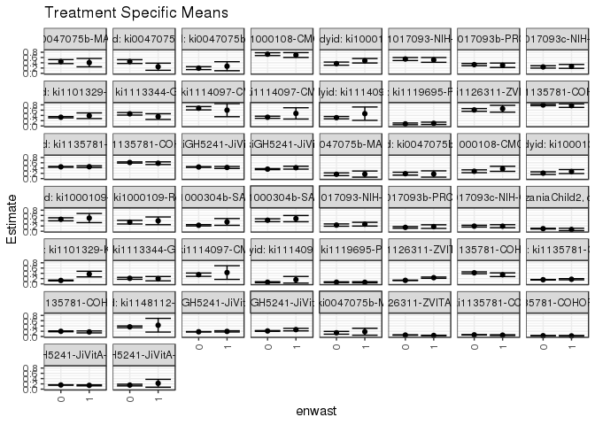

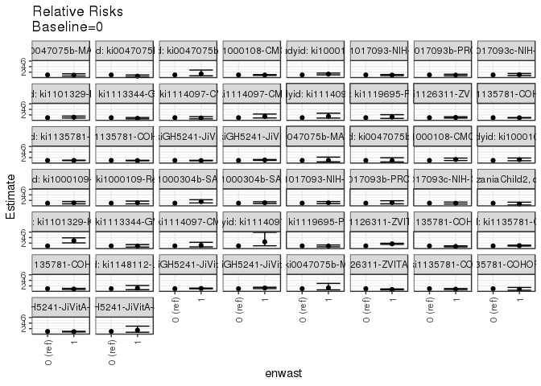

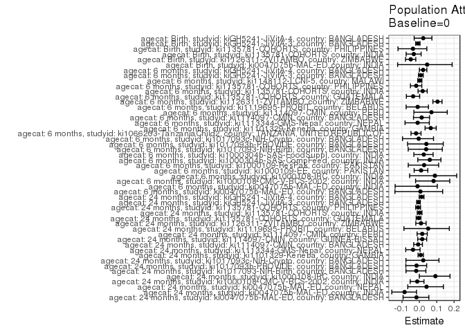

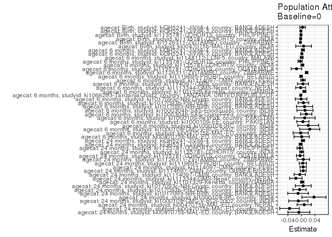

## Results Table

### Parameter: TSM

| agecat | studyid | country | intervention_level | baseline_level | estimate | ci_lower | ci_upper |
| --- | --- | --- | --- | --- | --- | --- | --- |
| Birth | ki0047075b-MAL-ED | INDIA | 0 | NA | 0.1411765 | 0.0887043 | 0.1936486 |
| Birth | ki0047075b-MAL-ED | INDIA | 1 | NA | 0.1818182 | 0.0498993 | 0.3137371 |
| Birth | ki1126311-ZVITAMBO | ZIMBABWE | 0 | NA | 0.0556374 | 0.0513254 | 0.0599495 |
| Birth | ki1126311-ZVITAMBO | ZIMBABWE | 1 | NA | 0.0402505 | 0.0321035 | 0.0483974 |
| Birth | ki1135781-COHORTS | INDIA | 0 | NA | 0.0637630 | 0.0570548 | 0.0704711 |
| Birth | ki1135781-COHORTS | INDIA | 1 | NA | 0.0529101 | 0.0398802 | 0.0659400 |
| Birth | ki1135781-COHORTS | PHILIPPINES | 0 | NA | 0.0306373 | 0.0238094 | 0.0374651 |
| Birth | ki1135781-COHORTS | PHILIPPINES | 1 | NA | 0.0238095 | 0.0099054 | 0.0377137 |
| Birth | kiGH5241-JiVitA-3 | BANGLADESH | 0 | NA | 0.1582060 | 0.1515864 | 0.1648256 |
| Birth | kiGH5241-JiVitA-3 | BANGLADESH | 1 | NA | 0.1446174 | 0.1256148 | 0.1636201 |
| Birth | kiGH5241-JiVitA-4 | BANGLADESH | 0 | NA | 0.1545595 | 0.1236384 | 0.1854806 |
| Birth | kiGH5241-JiVitA-4 | BANGLADESH | 1 | NA | 0.2222222 | 0.0728779 | 0.3715666 |
| 6 months | ki0047075b-MAL-ED | BANGLADESH | 0 | NA | 0.1648936 | 0.1117327 | 0.2180545 |
| 6 months | ki0047075b-MAL-ED | BANGLADESH | 1 | NA | 0.1707317 | 0.0553037 | 0.2861597 |
| 6 months | ki0047075b-MAL-ED | INDIA | 0 | NA | 0.1865285 | 0.1314544 | 0.2416026 |
| 6 months | ki0047075b-MAL-ED | INDIA | 1 | NA | 0.1750000 | 0.0569956 | 0.2930044 |
| 6 months | ki1000108-CMC-V-BCS-2002 | INDIA | 0 | NA | 0.2781955 | 0.2242704 | 0.3321206 |
| 6 months | ki1000108-CMC-V-BCS-2002 | INDIA | 1 | NA | 0.3711340 | 0.2748608 | 0.4674073 |
| 6 months | ki1000108-IRC | INDIA | 0 | NA | 0.2070313 | 0.1573336 | 0.2567289 |
| 6 months | ki1000108-IRC | INDIA | 1 | NA | 0.2671756 | 0.1913051 | 0.3430460 |
| 6 months | ki1000109-EE | PAKISTAN | 0 | NA | 0.4523810 | 0.3953996 | 0.5093623 |
| 6 months | ki1000109-EE | PAKISTAN | 1 | NA | 0.5000000 | 0.3264957 | 0.6735043 |
| 6 months | ki1000109-ResPak | PAKISTAN | 0 | NA | 0.3442623 | 0.2752708 | 0.4132538 |
| 6 months | ki1000109-ResPak | PAKISTAN | 1 | NA | 0.3953488 | 0.2488887 | 0.5418090 |
| 6 months | ki1000304b-SAS-CompFeed | INDIA | 0 | NA | 0.2262570 | 0.2027031 | 0.2498109 |
| 6 months | ki1000304b-SAS-CompFeed | INDIA | 1 | NA | 0.3525180 | 0.2244576 | 0.4805784 |
| 6 months | ki1000304b-SAS-FoodSuppl | INDIA | 0 | NA | 0.4180064 | 0.3631168 | 0.4728961 |
| 6 months | ki1000304b-SAS-FoodSuppl | INDIA | 1 | NA | 0.4782609 | 0.3602411 | 0.5962807 |
| 6 months | ki1017093-NIH-Birth | BANGLADESH | 0 | NA | 0.2336957 | 0.1904171 | 0.2769742 |
| 6 months | ki1017093-NIH-Birth | BANGLADESH | 1 | NA | 0.2671233 | 0.1952834 | 0.3389632 |

[output cut: 70 more lines]

### Parameter: E(Y)

| agecat | studyid | country | intervention_level | baseline_level | estimate | ci_lower | ci_upper |
| --- | --- | --- | --- | --- | --- | --- | --- |
| Birth | ki0047075b-MAL-ED | INDIA | NA | NA | 0.1477833 | 0.0988437 | 0.1967228 |
| Birth | ki1126311-ZVITAMBO | ZIMBABWE | NA | NA | 0.0530095 | 0.0491714 | 0.0568475 |
| Birth | ki1135781-COHORTS | INDIA | NA | NA | 0.0617878 | 0.0558091 | 0.0677665 |
| Birth | ki1135781-COHORTS | PHILIPPINES | NA | NA | 0.0295533 | 0.0233992 | 0.0357074 |
| Birth | kiGH5241-JiVitA-3 | BANGLADESH | NA | NA | 0.1568752 | 0.1505743 | 0.1631761 |
| Birth | kiGH5241-JiVitA-4 | BANGLADESH | NA | NA | 0.1581259 | 0.1278797 | 0.1883722 |
| 6 months | ki0047075b-MAL-ED | BANGLADESH | NA | NA | 0.1659389 | 0.1176493 | 0.2142285 |
| 6 months | ki0047075b-MAL-ED | INDIA | NA | NA | 0.1845494 | 0.1346311 | 0.2344676 |
| 6 months | ki1000108-CMC-V-BCS-2002 | INDIA | NA | NA | 0.3030303 | 0.2556886 | 0.3503720 |
| 6 months | ki1000108-IRC | INDIA | NA | NA | 0.2273902 | 0.1855763 | 0.2692041 |
| 6 months | ki1000109-EE | PAKISTAN | NA | NA | 0.4570552 | 0.4028965 | 0.5112140 |
| 6 months | ki1000109-ResPak | PAKISTAN | NA | NA | 0.3539823 | 0.2914982 | 0.4164664 |
| 6 months | ki1000304b-SAS-CompFeed | INDIA | NA | NA | 0.2407255 | 0.2138448 | 0.2676061 |
| 6 months | ki1000304b-SAS-FoodSuppl | INDIA | NA | NA | 0.4289474 | 0.3791199 | 0.4787748 |
| 6 months | ki1017093-NIH-Birth | BANGLADESH | NA | NA | 0.2431907 | 0.2060665 | 0.2803148 |
| 6 months | ki1017093b-PROVIDE | BANGLADESH | NA | NA | 0.1527778 | 0.1233713 | 0.1821843 |
| 6 months | ki1017093c-NIH-Crypto | BANGLADESH | NA | NA | 0.1930836 | 0.1636957 | 0.2224715 |
| 6 months | ki1066203-TanzaniaChild2 | TANZANIA, UNITED REPUBLIC OF | NA | NA | 0.0960396 | 0.0831873 | 0.1088919 |
| 6 months | ki1101329-Keneba | GAMBIA | NA | NA | 0.1385948 | 0.1237352 | 0.1534544 |
| 6 months | ki1113344-GMS-Nepal | NEPAL | NA | NA | 0.2085561 | 0.1749069 | 0.2422054 |
| 6 months | ki1114097-CMIN | BANGLADESH | NA | NA | 0.3534483 | 0.2918020 | 0.4150945 |
| 6 months | ki1114097-CMIN | PERU | NA | NA | 0.0675039 | 0.0480051 | 0.0870027 |
| 6 months | ki1119695-PROBIT | BELARUS | NA | NA | 0.0625873 | 0.0488338 | 0.0763408 |
| 6 months | ki1126311-ZVITAMBO | ZIMBABWE | NA | NA | 0.1497769 | 0.1418798 | 0.1576740 |
| 6 months | ki1135781-COHORTS | GUATEMALA | NA | NA | 0.4062153 | 0.3741290 | 0.4383016 |
| 6 months | ki1135781-COHORTS | INDIA | NA | NA | 0.1611862 | 0.1522521 | 0.1701204 |
| 6 months | ki1135781-COHORTS | PHILIPPINES | NA | NA | 0.1932125 | 0.1780130 | 0.2084119 |
| 6 months | ki1148112-LCNI-5 | MALAWI | NA | NA | 0.3682956 | 0.3356382 | 0.4009530 |
| 6 months | kiGH5241-JiVitA-3 | BANGLADESH | NA | NA | 0.1811658 | 0.1735678 | 0.1887638 |
| 6 months | kiGH5241-JiVitA-4 | BANGLADESH | NA | NA | 0.2150987 | 0.2013243 | 0.2288732 |
| 24 months | ki0047075b-MAL-ED | BANGLADESH | NA | NA | 0.4378109 | 0.3690538 | 0.5065681 |
| 24 months | ki0047075b-MAL-ED | INDIA | NA | NA | 0.4107143 | 0.3461446 | 0.4752839 |
| 24 months | ki0047075b-MAL-ED | NEPAL | NA | NA | 0.2044444 | 0.1516307 | 0.2572582 |
| 24 months | ki1000108-CMC-V-BCS-2002 | INDIA | NA | NA | 0.7178082 | 0.6715729 | 0.7640435 |
| 24 months | ki1000108-IRC | INDIA | NA | NA | 0.4046392 | 0.3557383 | 0.4535401 |
| 24 months | ki1017093-NIH-Birth | BANGLADESH | NA | NA | 0.5330073 | 0.4845968 | 0.5814178 |
| 24 months | ki1017093b-PROVIDE | BANGLADESH | NA | NA | 0.3251318 | 0.2866094 | 0.3636542 |
| 24 months | ki1017093c-NIH-Crypto | BANGLADESH | NA | NA | 0.2480000 | 0.2101093 | 0.2858907 |
| 24 months | ki1101329-Keneba | GAMBIA | NA | NA | 0.3333333 | 0.3110228 | 0.3556439 |
| 24 months | ki1113344-GMS-Nepal | NEPAL | NA | NA | 0.4446680 | 0.4009358 | 0.4884002 |
| 24 months | ki1114097-CMIN | BANGLADESH | NA | NA | 0.6681034 | 0.6073788 | 0.7288281 |
| 24 months | ki1114097-CMIN | GUINEA-BISSAU | NA | NA | 0.3357664 | 0.2961903 | 0.3753426 |
| 24 months | ki1114097-CMIN | PERU | NA | NA | 0.3193473 | 0.2751780 | 0.3635166 |
| 24 months | ki1119695-PROBIT | BELARUS | NA | NA | 0.0850694 | 0.0559313 | 0.1142076 |
| 24 months | ki1126311-ZVITAMBO | ZIMBABWE | NA | NA | 0.6140351 | 0.5662077 | 0.6618625 |
| 24 months | ki1135781-COHORTS | GUATEMALA | NA | NA | 0.7920311 | 0.7672214 | 0.8168408 |
| 24 months | ki1135781-COHORTS | INDIA | NA | NA | 0.4466575 | 0.4329730 | 0.4603419 |
| 24 months | ki1135781-COHORTS | PHILIPPINES | NA | NA | 0.6075841 | 0.5878253 | 0.6273430 |
| 24 months | kiGH5241-JiVitA-3 | BANGLADESH | NA | NA | 0.4379026 | 0.4237391 | 0.4520661 |
| 24 months | kiGH5241-JiVitA-4 | BANGLADESH | NA | NA | 0.3641880 | 0.3463720 | 0.3820040 |

### Parameter: RR

| agecat | studyid | country | intervention_level | baseline_level | estimate | ci_lower | ci_upper |
| --- | --- | --- | --- | --- | --- | --- | --- |
| Birth | ki0047075b-MAL-ED | INDIA | 0 | 0 | 1.0000000 | 1.0000000 | 1.0000000 |
| Birth | ki0047075b-MAL-ED | INDIA | 1 | 0 | 1.2878788 | 0.5699441 | 2.9101656 |
| Birth | ki1126311-ZVITAMBO | ZIMBABWE | 0 | 0 | 1.0000000 | 1.0000000 | 1.0000000 |
| Birth | ki1126311-ZVITAMBO | ZIMBABWE | 1 | 0 | 0.7234419 | 0.5824737 | 0.8985268 |
| Birth | ki1135781-COHORTS | INDIA | 0 | 0 | 1.0000000 | 1.0000000 | 1.0000000 |
| Birth | ki1135781-COHORTS | INDIA | 1 | 0 | 0.8297924 | 0.6348444 | 1.0846051 |
| Birth | ki1135781-COHORTS | PHILIPPINES | 0 | 0 | 1.0000000 | 1.0000000 | 1.0000000 |
| Birth | ki1135781-COHORTS | PHILIPPINES | 1 | 0 | 0.7771429 | 0.4159519 | 1.4519732 |
| Birth | kiGH5241-JiVitA-3 | BANGLADESH | 0 | 0 | 1.0000000 | 1.0000000 | 1.0000000 |
| Birth | kiGH5241-JiVitA-3 | BANGLADESH | 1 | 0 | 0.9141082 | 0.7971048 | 1.0482859 |
| Birth | kiGH5241-JiVitA-4 | BANGLADESH | 0 | 0 | 1.0000000 | 1.0000000 | 1.0000000 |
| Birth | kiGH5241-JiVitA-4 | BANGLADESH | 1 | 0 | 1.4377778 | 0.7114932 | 2.9054456 |
| 6 months | ki0047075b-MAL-ED | BANGLADESH | 0 | 0 | 1.0000000 | 1.0000000 | 1.0000000 |
| 6 months | ki0047075b-MAL-ED | BANGLADESH | 1 | 0 | 1.0354052 | 0.4895738 | 2.1897902 |
| 6 months | ki0047075b-MAL-ED | INDIA | 0 | 0 | 1.0000000 | 1.0000000 | 1.0000000 |
| 6 months | ki0047075b-MAL-ED | INDIA | 1 | 0 | 0.9381944 | 0.4493659 | 1.9587797 |
| 6 months | ki1000108-CMC-V-BCS-2002 | INDIA | 0 | 0 | 1.0000000 | 1.0000000 | 1.0000000 |
| 6 months | ki1000108-CMC-V-BCS-2002 | INDIA | 1 | 0 | 1.3340763 | 0.9650387 | 1.8442366 |
| 6 months | ki1000108-IRC | INDIA | 0 | 0 | 1.0000000 | 1.0000000 | 1.0000000 |
| 6 months | ki1000108-IRC | INDIA | 1 | 0 | 1.2905084 | 0.8897613 | 1.8717515 |
| 6 months | ki1000109-EE | PAKISTAN | 0 | 0 | 1.0000000 | 1.0000000 | 1.0000000 |
| 6 months | ki1000109-EE | PAKISTAN | 1 | 0 | 1.1052632 | 0.7640832 | 1.5987874 |
| 6 months | ki1000109-ResPak | PAKISTAN | 0 | 0 | 1.0000000 | 1.0000000 | 1.0000000 |
| 6 months | ki1000109-ResPak | PAKISTAN | 1 | 0 | 1.1483942 | 0.7536516 | 1.7498926 |
| 6 months | ki1000304b-SAS-CompFeed | INDIA | 0 | 0 | 1.0000000 | 1.0000000 | 1.0000000 |
| 6 months | ki1000304b-SAS-CompFeed | INDIA | 1 | 0 | 1.5580425 | 1.0796091 | 2.2484957 |
| 6 months | ki1000304b-SAS-FoodSuppl | INDIA | 0 | 0 | 1.0000000 | 1.0000000 | 1.0000000 |
| 6 months | ki1000304b-SAS-FoodSuppl | INDIA | 1 | 0 | 1.1441472 | 0.8651330 | 1.5131462 |
| 6 months | ki1017093-NIH-Birth | BANGLADESH | 0 | 0 | 1.0000000 | 1.0000000 | 1.0000000 |
| 6 months | ki1017093-NIH-Birth | BANGLADESH | 1 | 0 | 1.1430392 | 0.8246112 | 1.5844298 |

[output cut: 70 more lines]

### Parameter: PAR

| agecat | studyid | country | intervention_level | baseline_level | estimate | ci_lower | ci_upper |
| --- | --- | --- | --- | --- | --- | --- | --- |
| Birth | ki0047075b-MAL-ED | INDIA | 0 | NA | 0.0066068 | -0.0165648 | 0.0297784 |
| Birth | ki1126311-ZVITAMBO | ZIMBABWE | 0 | NA | -0.0026280 | -0.0042054 | -0.0010505 |
| Birth | ki1135781-COHORTS | INDIA | 0 | NA | -0.0019752 | -0.0046444 | 0.0006940 |
| Birth | ki1135781-COHORTS | PHILIPPINES | 0 | NA | -0.0010840 | -0.0035449 | 0.0013769 |
| Birth | kiGH5241-JiVitA-3 | BANGLADESH | 0 | NA | -0.0013308 | -0.0032900 | 0.0006283 |
| Birth | kiGH5241-JiVitA-4 | BANGLADESH | 0 | NA | 0.0035664 | -0.0045137 | 0.0116465 |
| 6 months | ki0047075b-MAL-ED | BANGLADESH | 0 | NA | 0.0010452 | -0.0217092 | 0.0237997 |
| 6 months | ki0047075b-MAL-ED | INDIA | 0 | NA | -0.0019791 | -0.0243421 | 0.0203838 |
| 6 months | ki1000108-CMC-V-BCS-2002 | INDIA | 0 | NA | 0.0248348 | -0.0049546 | 0.0546243 |
| 6 months | ki1000108-IRC | INDIA | 0 | NA | 0.0203589 | -0.0104736 | 0.0511914 |
| 6 months | ki1000109-EE | PAKISTAN | 0 | NA | 0.0046743 | -0.0133178 | 0.0226664 |
| 6 months | ki1000109-ResPak | PAKISTAN | 0 | NA | 0.0097200 | -0.0211945 | 0.0406345 |
| 6 months | ki1000304b-SAS-CompFeed | INDIA | 0 | NA | 0.0144685 | -0.0023016 | 0.0312386 |
| 6 months | ki1000304b-SAS-FoodSuppl | INDIA | 0 | NA | 0.0109409 | -0.0128087 | 0.0346906 |
| 6 months | ki1017093-NIH-Birth | BANGLADESH | 0 | NA | 0.0094950 | -0.0143634 | 0.0333534 |
| 6 months | ki1017093b-PROVIDE | BANGLADESH | 0 | NA | 0.0061695 | -0.0095318 | 0.0218708 |
| 6 months | ki1017093c-NIH-Crypto | BANGLADESH | 0 | NA | -0.0007149 | -0.0179292 | 0.0164995 |
| 6 months | ki1066203-TanzaniaChild2 | TANZANIA, UNITED REPUBLIC OF | 0 | NA | -0.0018036 | -0.0045870 | 0.0009797 |
| 6 months | ki1101329-Keneba | GAMBIA | 0 | NA | 0.0090948 | 0.0045734 | 0.0136162 |
| 6 months | ki1113344-GMS-Nepal | NEPAL | 0 | NA | -0.0020821 | -0.0166608 | 0.0124965 |
| 6 months | ki1114097-CMIN | BANGLADESH | 0 | NA | 0.0048244 | -0.0114980 | 0.0211468 |
| 6 months | ki1114097-CMIN | PERU | 0 | NA | 0.0046940 | -0.0018986 | 0.0112867 |
| 6 months | ki1119695-PROBIT | BELARUS | 0 | NA | -0.0006153 | -0.0046438 | 0.0034132 |
| 6 months | ki1126311-ZVITAMBO | ZIMBABWE | 0 | NA | 0.0156785 | 0.0116783 | 0.0196786 |
| 6 months | ki1135781-COHORTS | GUATEMALA | 0 | NA | -0.0144743 | -0.0300252 | 0.0010765 |
| 6 months | ki1135781-COHORTS | INDIA | 0 | NA | 0.0030953 | -0.0011476 | 0.0073381 |
| 6 months | ki1135781-COHORTS | PHILIPPINES | 0 | NA | -0.0035013 | -0.0098103 | 0.0028076 |
| 6 months | ki1148112-LCNI-5 | MALAWI | 0 | NA | 0.0010229 | -0.0033723 | 0.0054180 |
| 6 months | kiGH5241-JiVitA-3 | BANGLADESH | 0 | NA | 0.0015614 | -0.0009308 | 0.0040537 |
| 6 months | kiGH5241-JiVitA-4 | BANGLADESH | 0 | NA | 0.0047002 | 0.0001009 | 0.0092994 |
| 24 months | ki0047075b-MAL-ED | BANGLADESH | 0 | NA | -0.0073110 | -0.0397740 | 0.0251520 |
| 24 months | ki0047075b-MAL-ED | INDIA | 0 | NA | -0.0349379 | -0.0638983 | -0.0059775 |
| 24 months | ki0047075b-MAL-ED | NEPAL | 0 | NA | 0.0084645 | -0.0125139 | 0.0294430 |
| 24 months | ki1000108-CMC-V-BCS-2002 | INDIA | 0 | NA | -0.0087835 | -0.0372563 | 0.0196893 |
| 24 months | ki1000108-IRC | INDIA | 0 | NA | 0.0374517 | 0.0017572 | 0.0731462 |
| 24 months | ki1017093-NIH-Birth | BANGLADESH | 0 | NA | -0.0096548 | -0.0401833 | 0.0208737 |
| 24 months | ki1017093b-PROVIDE | BANGLADESH | 0 | NA | -0.0052451 | -0.0247193 | 0.0142291 |
| 24 months | ki1017093c-NIH-Crypto | BANGLADESH | 0 | NA | 0.0055758 | -0.0179926 | 0.0291441 |
| 24 months | ki1101329-Keneba | GAMBIA | 0 | NA | 0.0026487 | -0.0024734 | 0.0077709 |
| 24 months | ki1113344-GMS-Nepal | NEPAL | 0 | NA | -0.0161396 | -0.0344581 | 0.0021789 |
| 24 months | ki1114097-CMIN | BANGLADESH | 0 | NA | -0.0047076 | -0.0214330 | 0.0120178 |
| 24 months | ki1114097-CMIN | GUINEA-BISSAU | 0 | NA | 0.0055956 | -0.0030656 | 0.0142569 |
| 24 months | ki1114097-CMIN | PERU | 0 | NA | 0.0053377 | -0.0040226 | 0.0146979 |
| 24 months | ki1119695-PROBIT | BELARUS | 0 | NA | 0.0043261 | -0.0064812 | 0.0151334 |
| 24 months | ki1126311-ZVITAMBO | ZIMBABWE | 0 | NA | 0.0059659 | -0.0122527 | 0.0241845 |
| 24 months | ki1135781-COHORTS | GUATEMALA | 0 | NA | -0.0036310 | -0.0143122 | 0.0070501 |
| 24 months | ki1135781-COHORTS | INDIA | 0 | NA | 0.0007497 | -0.0052603 | 0.0067596 |
| 24 months | ki1135781-COHORTS | PHILIPPINES | 0 | NA | -0.0042811 | -0.0127387 | 0.0041765 |
| 24 months | kiGH5241-JiVitA-3 | BANGLADESH | 0 | NA | -0.0020943 | -0.0066462 | 0.0024576 |
| 24 months | kiGH5241-JiVitA-4 | BANGLADESH | 0 | NA | 0.0047194 | -0.0002656 | 0.0097044 |

### Parameter: PAF

| agecat | studyid | country | intervention_level | baseline_level | estimate | ci_lower | ci_upper |
| --- | --- | --- | --- | --- | --- | --- | --- |
| Birth | ki0047075b-MAL-ED | INDIA | 0 | NA | 0.0447059 | -0.1251384 | 0.1889115 |
| Birth | ki1126311-ZVITAMBO | ZIMBABWE | 0 | NA | -0.0495754 | -0.0795614 | -0.0204222 |
| Birth | ki1135781-COHORTS | INDIA | 0 | NA | -0.0319669 | -0.0759832 | 0.0102489 |
| Birth | ki1135781-COHORTS | PHILIPPINES | 0 | NA | -0.0366792 | -0.1230298 | 0.0430318 |
| Birth | kiGH5241-JiVitA-3 | BANGLADESH | 0 | NA | -0.0084832 | -0.0210503 | 0.0039291 |
| Birth | kiGH5241-JiVitA-4 | BANGLADESH | 0 | NA | 0.0225542 | -0.0298726 | 0.0723122 |
| 6 months | ki0047075b-MAL-ED | BANGLADESH | 0 | NA | 0.0062990 | -0.1407298 | 0.1343772 |
| 6 months | ki0047075b-MAL-ED | INDIA | 0 | NA | -0.0107242 | -0.1394422 | 0.1034531 |
| 6 months | ki1000108-CMC-V-BCS-2002 | INDIA | 0 | NA | 0.0819549 | -0.0216193 | 0.1750285 |
| 6 months | ki1000108-IRC | INDIA | 0 | NA | 0.0895330 | -0.0561379 | 0.2151119 |
| 6 months | ki1000109-EE | PAKISTAN | 0 | NA | 0.0102269 | -0.0299446 | 0.0488316 |
| 6 months | ki1000109-ResPak | PAKISTAN | 0 | NA | 0.0274590 | -0.0639254 | 0.1109941 |
| 6 months | ki1000304b-SAS-CompFeed | INDIA | 0 | NA | 0.0601037 | -0.0088883 | 0.1243777 |
| 6 months | ki1000304b-SAS-FoodSuppl | INDIA | 0 | NA | 0.0255065 | -0.0315029 | 0.0793650 |
| 6 months | ki1017093-NIH-Birth | BANGLADESH | 0 | NA | 0.0390435 | -0.0641683 | 0.1322450 |
| 6 months | ki1017093b-PROVIDE | BANGLADESH | 0 | NA | 0.0403819 | -0.0678812 | 0.1376693 |
| 6 months | ki1017093c-NIH-Crypto | BANGLADESH | 0 | NA | -0.0037024 | -0.0969358 | 0.0816067 |
| 6 months | ki1066203-TanzaniaChild2 | TANZANIA, UNITED REPUBLIC OF | 0 | NA | -0.0187801 | -0.0480893 | 0.0097095 |
| 6 months | ki1101329-Keneba | GAMBIA | 0 | NA | 0.0656215 | 0.0329762 | 0.0971648 |
| 6 months | ki1113344-GMS-Nepal | NEPAL | 0 | NA | -0.0099836 | -0.0823531 | 0.0575470 |
| 6 months | ki1114097-CMIN | BANGLADESH | 0 | NA | 0.0136496 | -0.0336341 | 0.0587702 |
| 6 months | ki1114097-CMIN | PERU | 0 | NA | 0.0695368 | -0.0314343 | 0.1606235 |
| 6 months | ki1119695-PROBIT | BELARUS | 0 | NA | -0.0098311 | -0.0760957 | 0.0523531 |
| 6 months | ki1126311-ZVITAMBO | ZIMBABWE | 0 | NA | 0.1046788 | 0.0779744 | 0.1306098 |
| 6 months | ki1135781-COHORTS | GUATEMALA | 0 | NA | -0.0356322 | -0.0746756 | 0.0019928 |
| 6 months | ki1135781-COHORTS | INDIA | 0 | NA | 0.0192030 | -0.0074625 | 0.0451627 |
| 6 months | ki1135781-COHORTS | PHILIPPINES | 0 | NA | -0.0181217 | -0.0512873 | 0.0139977 |
| 6 months | ki1148112-LCNI-5 | MALAWI | 0 | NA | 0.0027773 | -0.0092285 | 0.0146403 |
| 6 months | kiGH5241-JiVitA-3 | BANGLADESH | 0 | NA | 0.0086187 | -0.0052016 | 0.0222490 |
| 6 months | kiGH5241-JiVitA-4 | BANGLADESH | 0 | NA | 0.0218511 | 0.0001654 | 0.0430665 |
| 24 months | ki0047075b-MAL-ED | BANGLADESH | 0 | NA | -0.0166990 | -0.0936474 | 0.0548354 |
| 24 months | ki0047075b-MAL-ED | INDIA | 0 | NA | -0.0850662 | -0.1586106 | -0.0161901 |
| 24 months | ki0047075b-MAL-ED | NEPAL | 0 | NA | 0.0414027 | -0.0665873 | 0.1384589 |
| 24 months | ki1000108-CMC-V-BCS-2002 | INDIA | 0 | NA | -0.0122366 | -0.0527241 | 0.0266938 |
| 24 months | ki1000108-IRC | INDIA | 0 | NA | 0.0925557 | -0.0002698 | 0.1767670 |
| 24 months | ki1017093-NIH-Birth | BANGLADESH | 0 | NA | -0.0181138 | -0.0770645 | 0.0376104 |
| 24 months | ki1017093b-PROVIDE | BANGLADESH | 0 | NA | -0.0161323 | -0.0778285 | 0.0420323 |
| 24 months | ki1017093c-NIH-Crypto | BANGLADESH | 0 | NA | 0.0224829 | -0.0772995 | 0.1130232 |
| 24 months | ki1101329-Keneba | GAMBIA | 0 | NA | 0.0079462 | -0.0075397 | 0.0231941 |
| 24 months | ki1113344-GMS-Nepal | NEPAL | 0 | NA | -0.0362958 | -0.0784276 | 0.0041899 |
| 24 months | ki1114097-CMIN | BANGLADESH | 0 | NA | -0.0070462 | -0.0324198 | 0.0177037 |
| 24 months | ki1114097-CMIN | GUINEA-BISSAU | 0 | NA | 0.0166653 | -0.0094711 | 0.0421250 |
| 24 months | ki1114097-CMIN | PERU | 0 | NA | 0.0167143 | -0.0130303 | 0.0455855 |
| 24 months | ki1119695-PROBIT | BELARUS | 0 | NA | 0.0508537 | -0.0889096 | 0.1726781 |
| 24 months | ki1126311-ZVITAMBO | ZIMBABWE | 0 | NA | 0.0097159 | -0.0204247 | 0.0389663 |
| 24 months | ki1135781-COHORTS | GUATEMALA | 0 | NA | -0.0045844 | -0.0181663 | 0.0088163 |
| 24 months | ki1135781-COHORTS | INDIA | 0 | NA | 0.0016784 | -0.0118681 | 0.0150435 |
| 24 months | ki1135781-COHORTS | PHILIPPINES | 0 | NA | -0.0070461 | -0.0210669 | 0.0067821 |
| 24 months | kiGH5241-JiVitA-3 | BANGLADESH | 0 | NA | -0.0047825 | -0.0152346 | 0.0055620 |
| 24 months | kiGH5241-JiVitA-4 | BANGLADESH | 0 | NA | 0.0129586 | -0.0008579 | 0.0265844 |